# Risk Factor Analysis

## Outcome Variable

**Outcome Variable:** haz

## Predictor Variables

**Intervention Variable:** pers_wast

**Adjustment Set:**

- arm
- sex
- brthmon
- W_mage
- meducyrs
- hhwealth_quart
- W_nrooms
- month
- W_parity
- delta_W_mage
- delta_meducyrs
- delta_hhwealth_quart
- delta_W_nrooms
- delta_month
- delta_W_parity

## Stratifying Variables

The analysis was stratified on these variable(s):

- agecat
- studyid
- country

## Data Summary

| agecat | studyid | country | pers_wast | n_cell | n |
| --- | --- | --- | --- | --- | --- |
| Birth | CMC-V-BCS-2002 | INDIA | 0 | 80 | 92 |
| Birth | CMC-V-BCS-2002 | INDIA | 1 | 12 | 92 |
| Birth | CMIN | BANGLADESH | 0 | 16 | 18 |
| Birth | CMIN | BANGLADESH | 1 | 2 | 18 |
| Birth | CONTENT | PERU | 0 | 2 | 2 |
| Birth | CONTENT | PERU | 1 | 0 | 2 |
| Birth | EE | PAKISTAN | 0 | 224 | 240 |
| Birth | EE | PAKISTAN | 1 | 16 | 240 |
| Birth | GMS-Nepal | NEPAL | 0 | 521 | 585 |
| Birth | GMS-Nepal | NEPAL | 1 | 64 | 585 |
| Birth | IRC | INDIA | 0 | 319 | 387 |
| Birth | IRC | INDIA | 1 | 68 | 387 |
| Birth | Keneba | GAMBIA | 0 | 1374 | 1419 |
| Birth | Keneba | GAMBIA | 1 | 45 | 1419 |
| Birth | MAL-ED | BANGLADESH | 0 | 220 | 229 |
| Birth | MAL-ED | BANGLADESH | 1 | 9 | 229 |
| Birth | MAL-ED | BRAZIL | 0 | 65 | 65 |
| Birth | MAL-ED | BRAZIL | 1 | 0 | 65 |
| Birth | MAL-ED | INDIA | 0 | 43 | 45 |
| Birth | MAL-ED | INDIA | 1 | 2 | 45 |
| Birth | MAL-ED | NEPAL | 0 | 26 | 27 |
| Birth | MAL-ED | NEPAL | 1 | 1 | 27 |
| Birth | MAL-ED | PERU | 0 | 233 | 233 |
| Birth | MAL-ED | PERU | 1 | 0 | 233 |
| Birth | MAL-ED | SOUTH AFRICA | 0 | 111 | 113 |
| Birth | MAL-ED | SOUTH AFRICA | 1 | 2 | 113 |
| Birth | MAL-ED | TANZANIA, UNITED REPUBLIC OF | 0 | 123 | 123 |
| Birth | MAL-ED | TANZANIA, UNITED REPUBLIC OF | 1 | 0 | 123 |
| Birth | PROVIDE | BANGLADESH | 0 | 516 | 539 |
| Birth | PROVIDE | BANGLADESH | 1 | 23 | 539 |

[output cut: 70 more lines]

The following strata were considered:

- agecat: 24 months, studyid: CMC-V-BCS-2002, country: INDIA
- agecat: 24 months, studyid: CMIN, country: BANGLADESH
- agecat: 24 months, studyid: CONTENT, country: PERU
- agecat: 24 months, studyid: EE, country: PAKISTAN
- agecat: 24 months, studyid: GMS-Nepal, country: NEPAL
- agecat: 24 months, studyid: IRC, country: INDIA
- agecat: 24 months, studyid: Keneba, country: GAMBIA
- agecat: 24 months, studyid: MAL-ED, country: BANGLADESH
- agecat: 24 months, studyid: MAL-ED, country: BRAZIL
- agecat: 24 months, studyid: MAL-ED, country: INDIA
- agecat: 24 months, studyid: MAL-ED, country: NEPAL
- agecat: 24 months, studyid: MAL-ED, country: PERU
- agecat: 24 months, studyid: MAL-ED, country: SOUTH AFRICA
- agecat: 24 months, studyid: MAL-ED, country: TANZANIA, UNITED REPUBLIC OF
- agecat: 24 months, studyid: PROVIDE, country: BANGLADESH
- agecat: 24 months, studyid: TanzaniaChild2, country: TANZANIA, UNITED REPUBLIC OF
- agecat: 6 months, studyid: CMC-V-BCS-2002, country: INDIA
- agecat: 6 months, studyid: CMIN, country: BANGLADESH
- agecat: 6 months, studyid: CONTENT, country: PERU
- agecat: 6 months, studyid: EE, country: PAKISTAN
- agecat: 6 months, studyid: GMS-Nepal, country: NEPAL
- agecat: 6 months, studyid: Guatemala BSC, country: GUATEMALA
- agecat: 6 months, studyid: IRC, country: INDIA
- agecat: 6 months, studyid: Keneba, country: GAMBIA
- agecat: 6 months, studyid: MAL-ED, country: BANGLADESH
- agecat: 6 months, studyid: MAL-ED, country: BRAZIL
- agecat: 6 months, studyid: MAL-ED, country: INDIA
- agecat: 6 months, studyid: MAL-ED, country: NEPAL
- agecat: 6 months, studyid: MAL-ED, country: PERU
- agecat: 6 months, studyid: MAL-ED, country: SOUTH AFRICA
- agecat: 6 months, studyid: MAL-ED, country: TANZANIA, UNITED REPUBLIC OF
- agecat: 6 months, studyid: PROVIDE, country: BANGLADESH
- agecat: 6 months, studyid: ResPak, country: PAKISTAN
- agecat: 6 months, studyid: TanzaniaChild2, country: TANZANIA, UNITED REPUBLIC OF
- agecat: Birth, studyid: CMC-V-BCS-2002, country: INDIA
- agecat: Birth, studyid: CMIN, country: BANGLADESH
- agecat: Birth, studyid: CONTENT, country: PERU
- agecat: Birth, studyid: EE, country: PAKISTAN
- agecat: Birth, studyid: GMS-Nepal, country: NEPAL
- agecat: Birth, studyid: IRC, country: INDIA
- agecat: Birth, studyid: Keneba, country: GAMBIA
- agecat: Birth, studyid: MAL-ED, country: BANGLADESH
- agecat: Birth, studyid: MAL-ED, country: BRAZIL
- agecat: Birth, studyid: MAL-ED, country: INDIA
- agecat: Birth, studyid: MAL-ED, country: NEPAL
- agecat: Birth, studyid: MAL-ED, country: PERU
- agecat: Birth, studyid: MAL-ED, country: SOUTH AFRICA
- agecat: Birth, studyid: MAL-ED, country: TANZANIA, UNITED REPUBLIC OF
- agecat: Birth, studyid: PROVIDE, country: BANGLADESH
- agecat: Birth, studyid: ResPak, country: PAKISTAN

### Dropped Strata

Some strata were dropped due to rare outcomes:

- agecat: Birth, studyid: CMIN, country: BANGLADESH
- agecat: Birth, studyid: CONTENT, country: PERU
- agecat: Birth, studyid: MAL-ED, country: BRAZIL
- agecat: Birth, studyid: MAL-ED, country: INDIA
- agecat: Birth, studyid: MAL-ED, country: NEPAL
- agecat: Birth, studyid: MAL-ED, country: PERU
- agecat: Birth, studyid: MAL-ED, country: SOUTH AFRICA
- agecat: Birth, studyid: MAL-ED, country: TANZANIA, UNITED REPUBLIC OF
- agecat: Birth, studyid: ResPak, country: PAKISTAN
- agecat: 6 months, studyid: CONTENT, country: PERU
- agecat: 6 months, studyid: MAL-ED, country: BRAZIL
- agecat: 6 months, studyid: MAL-ED, country: PERU
- agecat: 6 months, studyid: MAL-ED, country: SOUTH AFRICA
- agecat: 6 months, studyid: MAL-ED, country: TANZANIA, UNITED REPUBLIC OF
- agecat: 24 months, studyid: CONTENT, country: PERU
- agecat: 24 months, studyid: MAL-ED, country: BRAZIL
- agecat: 24 months, studyid: MAL-ED, country: PERU
- agecat: 24 months, studyid: MAL-ED, country: SOUTH AFRICA
- agecat: 24 months, studyid: MAL-ED, country: TANZANIA, UNITED REPUBLIC OF
- agecat: 24 months, studyid: TanzaniaChild2, country: TANZANIA, UNITED REPUBLIC OF

## Methods Detail

We’re interested in the causal parameters $E[Y_a]$ for all values of $a \in \mathcal{A}$. These parameters represent the mean outcome if, possibly contrary to fact, we intervened to set all units to have $A=a$. Under the randomization and positivity assumptions, these are identified by the statistical parameters $\psi_a=E_W[E_{Y|A,W}(Y|A=a,W)]$. In addition, we’re interested in the mean of $Y$, $E[Y]$ under no intervention (the observed mean). We will estimate these parameters by using SuperLearner to fit the relevant likelihood factors – $E_{Y|A,W}(Y|A=a,W)$ and $p(A=a|W)$, and then updating our likelihood fit using a joint TMLE.

For unadjusted analyses ($W=\{\}$), initial likelihoods were estimated using Lrnr_glm to estimate the simple $E(Y|A)$ and Lrnr_mean to estimate $p(A)$. For adjusted analyses, a small library containing Lrnr_glmnet, Lrnr_xgboost, and Lrnr_mean was used.

Having estimated these parameters, we will then use the delta method to estimate relative risks and attributable risks relative to a prespecified baseline level of $A$.

# Results Detail

## Results Plots

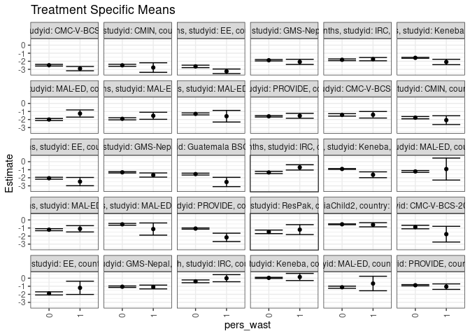

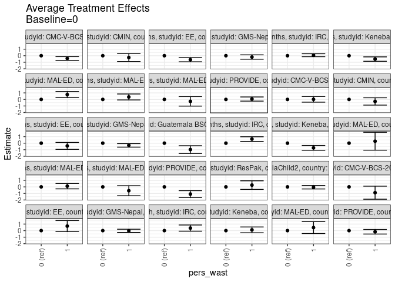

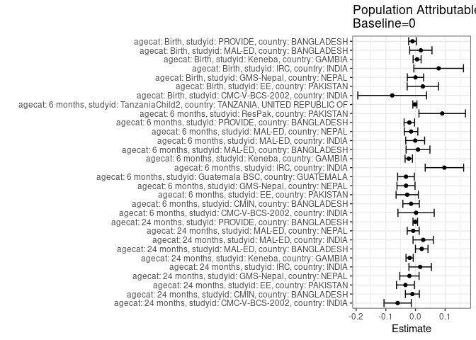

## Results Table

### Parameter: TSM

| agecat | studyid | country | intervention_level | baseline_level | estimate | ci_lower | ci_upper |
| --- | --- | --- | --- | --- | --- | --- | --- |
| Birth | CMC-V-BCS-2002 | INDIA | 0 | NA | -0.8827728 | -1.0977753 | -0.6677702 |
| Birth | CMC-V-BCS-2002 | INDIA | 1 | NA | -1.7675512 | -2.7411532 | -0.7939491 |
| Birth | EE | PAKISTAN | 0 | NA | -1.8857882 | -2.0799006 | -1.6916758 |
| Birth | EE | PAKISTAN | 1 | NA | -1.1946671 | -2.0175867 | -0.3717475 |
| Birth | GMS-Nepal | NEPAL | 0 | NA | -1.0554400 | -1.1474277 | -0.9634523 |
| Birth | GMS-Nepal | NEPAL | 1 | NA | -1.0921183 | -1.3257113 | -0.8585253 |
| Birth | IRC | INDIA | 0 | NA | -0.3899707 | -0.5622629 | -0.2176786 |
| Birth | IRC | INDIA | 1 | NA | -0.0019088 | -0.4411187 | 0.4373010 |
| Birth | Keneba | GAMBIA | 0 | NA | 0.0376734 | -0.0292885 | 0.1046353 |
| Birth | Keneba | GAMBIA | 1 | NA | 0.1500042 | -0.2907392 | 0.5907475 |
| Birth | MAL-ED | BANGLADESH | 0 | NA | -1.1222727 | -1.2564846 | -0.9880609 |
| Birth | MAL-ED | BANGLADESH | 1 | NA | -0.6600000 | -1.5592093 | 0.2392093 |
| Birth | PROVIDE | BANGLADESH | 0 | NA | -0.8750911 | -0.9524250 | -0.7977571 |
| Birth | PROVIDE | BANGLADESH | 1 | NA | -1.0495805 | -1.3909910 | -0.7081701 |
| 6 months | CMC-V-BCS-2002 | INDIA | 0 | NA | -1.4262740 | -1.5800661 | -1.2724820 |
| 6 months | CMC-V-BCS-2002 | INDIA | 1 | NA | -1.4099246 | -1.8154459 | -1.0044032 |
| 6 months | CMIN | BANGLADESH | 0 | NA | -1.7696626 | -1.9112513 | -1.6280738 |
| 6 months | CMIN | BANGLADESH | 1 | NA | -2.0759690 | -2.6187122 | -1.5332258 |
| 6 months | EE | PAKISTAN | 0 | NA | -2.0557243 | -2.1777882 | -1.9336604 |
| 6 months | EE | PAKISTAN | 1 | NA | -2.4727611 | -2.9864235 | -1.9590987 |
| 6 months | GMS-Nepal | NEPAL | 0 | NA | -1.3214183 | -1.4033471 | -1.2394895 |
| 6 months | GMS-Nepal | NEPAL | 1 | NA | -1.6575364 | -1.9166046 | -1.3984682 |
| 6 months | Guatemala BSC | GUATEMALA | 0 | NA | -1.5415418 | -1.6567941 | -1.4262896 |
| 6 months | Guatemala BSC | GUATEMALA | 1 | NA | -2.5211111 | -3.0985428 | -1.9436794 |
| 6 months | IRC | INDIA | 0 | NA | -1.3359328 | -1.4758917 | -1.1959739 |
| 6 months | IRC | INDIA | 1 | NA | -0.7101635 | -1.0390930 | -0.3812340 |
| 6 months | Keneba | GAMBIA | 0 | NA | -0.9055966 | -0.9544806 | -0.8567125 |
| 6 months | Keneba | GAMBIA | 1 | NA | -1.6262534 | -1.9870414 | -1.2654654 |
| 6 months | MAL-ED | BANGLADESH | 0 | NA | -1.2135826 | -1.3270160 | -1.1001493 |
| 6 months | MAL-ED | BANGLADESH | 1 | NA | -0.9178571 | -2.2823123 | 0.4465980 |
| 6 months | MAL-ED | INDIA | 0 | NA | -1.2105608 | -1.3345698 | -1.0865518 |
| 6 months | MAL-ED | INDIA | 1 | NA | -1.1008468 | -1.4924247 | -0.7092690 |
| 6 months | MAL-ED | NEPAL | 0 | NA | -0.5467101 | -0.6599035 | -0.4335168 |
| 6 months | MAL-ED | NEPAL | 1 | NA | -1.1316667 | -1.8892005 | -0.3741328 |
| 6 months | PROVIDE | BANGLADESH | 0 | NA | -1.0709708 | -1.1456091 | -0.9963326 |
| 6 months | PROVIDE | BANGLADESH | 1 | NA | -2.1670170 | -2.6880570 | -1.6459770 |
| 6 months | ResPak | PAKISTAN | 0 | NA | -1.4775609 | -1.6976979 | -1.2574239 |
| 6 months | ResPak | PAKISTAN | 1 | NA | -1.2022616 | -1.8180451 | -0.5864781 |
| 6 months | TanzaniaChild2 | TANZANIA, UNITED REPUBLIC OF | 0 | NA | -0.5431209 | -0.5930765 | -0.4931652 |
| 6 months | TanzaniaChild2 | TANZANIA, UNITED REPUBLIC OF | 1 | NA | -0.5987907 | -0.8563351 | -0.3412463 |
| 24 months | CMC-V-BCS-2002 | INDIA | 0 | NA | -2.4887891 | -2.5940034 | -2.3835749 |
| 24 months | CMC-V-BCS-2002 | INDIA | 1 | NA | -2.9116039 | -3.1778313 | -2.6453765 |
| 24 months | CMIN | BANGLADESH | 0 | NA | -2.5005794 | -2.6283894 | -2.3727694 |
| 24 months | CMIN | BANGLADESH | 1 | NA | -2.7794444 | -3.3734067 | -2.1854822 |
| 24 months | EE | PAKISTAN | 0 | NA | -2.6362122 | -2.7873365 | -2.4850880 |
| 24 months | EE | PAKISTAN | 1 | NA | -3.2472785 | -3.5318100 | -2.9627471 |
| 24 months | GMS-Nepal | NEPAL | 0 | NA | -1.8735019 | -1.9623648 | -1.7846389 |
| 24 months | GMS-Nepal | NEPAL | 1 | NA | -2.0741155 | -2.3944284 | -1.7538026 |
| 24 months | IRC | INDIA | 0 | NA | -1.8147663 | -1.9198492 | -1.7096834 |
| 24 months | IRC | INDIA | 1 | NA | -1.7389590 | -1.9419109 | -1.5360071 |
| 24 months | Keneba | GAMBIA | 0 | NA | -1.5727277 | -1.6269952 | -1.5184603 |
| 24 months | Keneba | GAMBIA | 1 | NA | -2.0880663 | -2.4204639 | -1.7556687 |
| 24 months | MAL-ED | BANGLADESH | 0 | NA | -1.9994417 | -2.1279716 | -1.8709119 |
| 24 months | MAL-ED | BANGLADESH | 1 | NA | -1.2558333 | -1.7012482 | -0.8104185 |
| 24 months | MAL-ED | INDIA | 0 | NA | -1.9121875 | -2.0433408 | -1.7810342 |
| 24 months | MAL-ED | INDIA | 1 | NA | -1.5351236 | -1.9718098 | -1.0984373 |
| 24 months | MAL-ED | NEPAL | 0 | NA | -1.2999550 | -1.4209558 | -1.1789541 |
| 24 months | MAL-ED | NEPAL | 1 | NA | -1.5900000 | -2.3102086 | -0.8697914 |
| 24 months | PROVIDE | BANGLADESH | 0 | NA | -1.6017950 | -1.6869036 | -1.5166865 |
| 24 months | PROVIDE | BANGLADESH | 1 | NA | -1.5405176 | -1.8459390 | -1.2350963 |

### Parameter: E(Y)

| agecat | studyid | country | intervention_level | baseline_level | estimate | ci_lower | ci_upper |
| --- | --- | --- | --- | --- | --- | --- | --- |
| Birth | CMC-V-BCS-2002 | INDIA | NA | NA | -0.9611957 | -1.1776967 | -0.7446946 |
| Birth | EE | PAKISTAN | NA | NA | -1.8608750 | -2.0482045 | -1.6735455 |
| Birth | GMS-Nepal | NEPAL | NA | NA | -1.0554530 | -1.1411259 | -0.9697801 |
| Birth | IRC | INDIA | NA | NA | -0.3117313 | -0.4727359 | -0.1507267 |
| Birth | Keneba | GAMBIA | NA | NA | 0.0432135 | -0.0229516 | 0.1093787 |
| Birth | MAL-ED | BANGLADESH | NA | NA | -1.1041048 | -1.2383048 | -0.9699048 |
| Birth | PROVIDE | BANGLADESH | NA | NA | -0.8851020 | -0.9601332 | -0.8100709 |
| 6 months | CMC-V-BCS-2002 | INDIA | NA | NA | -1.4241872 | -1.5668135 | -1.2815609 |
| 6 months | CMIN | BANGLADESH | NA | NA | -1.7844376 | -1.9222926 | -1.6465825 |
| 6 months | EE | PAKISTAN | NA | NA | -2.0835567 | -2.2027557 | -1.9643578 |
| 6 months | GMS-Nepal | NEPAL | NA | NA | -1.3533244 | -1.4319426 | -1.2747062 |
| 6 months | Guatemala BSC | GUATEMALA | NA | NA | -1.5734843 | -1.6884116 | -1.4585570 |
| 6 months | IRC | INDIA | NA | NA | -1.2382964 | -1.3698449 | -1.1067479 |
| 6 months | Keneba | GAMBIA | NA | NA | -0.9282048 | -0.9770928 | -0.8793169 |
| 6 months | MAL-ED | BANGLADESH | NA | NA | -1.2049931 | -1.3222136 | -1.0877726 |
| 6 months | MAL-ED | INDIA | NA | NA | -1.2115254 | -1.3298727 | -1.0931782 |
| 6 months | MAL-ED | NEPAL | NA | NA | -0.5615819 | -0.6741832 | -0.4489807 |
| 6 months | PROVIDE | BANGLADESH | NA | NA | -1.0916915 | -1.1661176 | -1.0172654 |
| 6 months | ResPak | PAKISTAN | NA | NA | -1.3874523 | -1.5959323 | -1.1789723 |
| 6 months | TanzaniaChild2 | TANZANIA, UNITED REPUBLIC OF | NA | NA | -0.5450830 | -0.5941754 | -0.4959906 |
| 24 months | CMC-V-BCS-2002 | INDIA | NA | NA | -2.5489071 | -2.6476125 | -2.4502017 |
| 24 months | CMIN | BANGLADESH | NA | NA | -2.5109504 | -2.6361514 | -2.3857494 |
| 24 months | EE | PAKISTAN | NA | NA | -2.6699900 | -2.8138051 | -2.5261749 |
| 24 months | GMS-Nepal | NEPAL | NA | NA | -1.8938622 | -1.9795205 | -1.8082040 |
| 24 months | IRC | INDIA | NA | NA | -1.7989338 | -1.8927769 | -1.7050907 |
| 24 months | Keneba | GAMBIA | NA | NA | -1.5924094 | -1.6461889 | -1.5386298 |
| 24 months | MAL-ED | BANGLADESH | NA | NA | -1.9783962 | -2.1050210 | -1.8517715 |
| 24 months | MAL-ED | INDIA | NA | NA | -1.8861894 | -2.0110006 | -1.7613783 |
| 24 months | MAL-ED | NEPAL | NA | NA | -1.3075877 | -1.4270718 | -1.1881037 |
| 24 months | PROVIDE | BANGLADESH | NA | NA | -1.6024221 | -1.6857420 | -1.5191023 |

### Parameter: ATE

| agecat | studyid | country | intervention_level | baseline_level | estimate | ci_lower | ci_upper |
| --- | --- | --- | --- | --- | --- | --- | --- |
| Birth | CMC-V-BCS-2002 | INDIA | 0 | 0 | 0.0000000 | 0.0000000 | 0.0000000 |
| Birth | CMC-V-BCS-2002 | INDIA | 1 | 0 | -0.8847784 | -1.8820004 | 0.1124435 |
| Birth | EE | PAKISTAN | 0 | 0 | 0.0000000 | 0.0000000 | 0.0000000 |
| Birth | EE | PAKISTAN | 1 | 0 | 0.6911211 | -0.1597459 | 1.5419882 |
| Birth | GMS-Nepal | NEPAL | 0 | 0 | 0.0000000 | 0.0000000 | 0.0000000 |
| Birth | GMS-Nepal | NEPAL | 1 | 0 | -0.0366783 | -0.2877982 | 0.2144416 |
| Birth | IRC | INDIA | 0 | 0 | 0.0000000 | 0.0000000 | 0.0000000 |
| Birth | IRC | INDIA | 1 | 0 | 0.3880619 | -0.0853663 | 0.8614902 |
| Birth | Keneba | GAMBIA | 0 | 0 | 0.0000000 | 0.0000000 | 0.0000000 |
| Birth | Keneba | GAMBIA | 1 | 0 | 0.1123308 | -0.3333107 | 0.5579722 |
| Birth | MAL-ED | BANGLADESH | 0 | 0 | 0.0000000 | 0.0000000 | 0.0000000 |
| Birth | MAL-ED | BANGLADESH | 1 | 0 | 0.4622727 | -0.4468973 | 1.3714428 |
| Birth | PROVIDE | BANGLADESH | 0 | 0 | 0.0000000 | 0.0000000 | 0.0000000 |
| Birth | PROVIDE | BANGLADESH | 1 | 0 | -0.1744895 | -0.5242831 | 0.1753042 |
| 6 months | CMC-V-BCS-2002 | INDIA | 0 | 0 | 0.0000000 | 0.0000000 | 0.0000000 |
| 6 months | CMC-V-BCS-2002 | INDIA | 1 | 0 | 0.0163495 | -0.4193109 | 0.4520098 |
| 6 months | CMIN | BANGLADESH | 0 | 0 | 0.0000000 | 0.0000000 | 0.0000000 |
| 6 months | CMIN | BANGLADESH | 1 | 0 | -0.3063064 | -0.8666138 | 0.2540009 |
| 6 months | EE | PAKISTAN | 0 | 0 | 0.0000000 | 0.0000000 | 0.0000000 |
| 6 months | EE | PAKISTAN | 1 | 0 | -0.4170368 | -0.9462880 | 0.1122144 |
| 6 months | GMS-Nepal | NEPAL | 0 | 0 | 0.0000000 | 0.0000000 | 0.0000000 |
| 6 months | GMS-Nepal | NEPAL | 1 | 0 | -0.3361181 | -0.6079145 | -0.0643217 |
| 6 months | Guatemala BSC | GUATEMALA | 0 | 0 | 0.0000000 | 0.0000000 | 0.0000000 |
| 6 months | Guatemala BSC | GUATEMALA | 1 | 0 | -0.9795693 | -1.5683905 | -0.3907481 |
| 6 months | IRC | INDIA | 0 | 0 | 0.0000000 | 0.0000000 | 0.0000000 |
| 6 months | IRC | INDIA | 1 | 0 | 0.6257693 | 0.2694947 | 0.9820438 |
| 6 months | Keneba | GAMBIA | 0 | 0 | 0.0000000 | 0.0000000 | 0.0000000 |
| 6 months | Keneba | GAMBIA | 1 | 0 | -0.7206568 | -1.0849366 | -0.3563771 |
| 6 months | MAL-ED | BANGLADESH | 0 | 0 | 0.0000000 | 0.0000000 | 0.0000000 |
| 6 months | MAL-ED | BANGLADESH | 1 | 0 | 0.2957255 | -1.0734367 | 1.6648877 |
| 6 months | MAL-ED | INDIA | 0 | 0 | 0.0000000 | 0.0000000 | 0.0000000 |
| 6 months | MAL-ED | INDIA | 1 | 0 | 0.1097140 | -0.3008667 | 0.5202947 |
| 6 months | MAL-ED | NEPAL | 0 | 0 | 0.0000000 | 0.0000000 | 0.0000000 |
| 6 months | MAL-ED | NEPAL | 1 | 0 | -0.5849565 | -1.3509005 | 0.1809875 |
| 6 months | PROVIDE | BANGLADESH | 0 | 0 | 0.0000000 | 0.0000000 | 0.0000000 |
| 6 months | PROVIDE | BANGLADESH | 1 | 0 | -1.0960462 | -1.6219429 | -0.5701494 |
| 6 months | ResPak | PAKISTAN | 0 | 0 | 0.0000000 | 0.0000000 | 0.0000000 |
| 6 months | ResPak | PAKISTAN | 1 | 0 | 0.2752993 | -0.3821535 | 0.9327522 |
| 6 months | TanzaniaChild2 | TANZANIA, UNITED REPUBLIC OF | 0 | 0 | 0.0000000 | 0.0000000 | 0.0000000 |
| 6 months | TanzaniaChild2 | TANZANIA, UNITED REPUBLIC OF | 1 | 0 | -0.0556698 | -0.3178784 | 0.2065388 |
| 24 months | CMC-V-BCS-2002 | INDIA | 0 | 0 | 0.0000000 | 0.0000000 | 0.0000000 |
| 24 months | CMC-V-BCS-2002 | INDIA | 1 | 0 | -0.4228148 | -0.7090193 | -0.1366102 |
| 24 months | CMIN | BANGLADESH | 0 | 0 | 0.0000000 | 0.0000000 | 0.0000000 |
| 24 months | CMIN | BANGLADESH | 1 | 0 | -0.2788650 | -0.8864229 | 0.3286928 |
| 24 months | EE | PAKISTAN | 0 | 0 | 0.0000000 | 0.0000000 | 0.0000000 |
| 24 months | EE | PAKISTAN | 1 | 0 | -0.6110663 | -0.9323340 | -0.2897986 |
| 24 months | GMS-Nepal | NEPAL | 0 | 0 | 0.0000000 | 0.0000000 | 0.0000000 |
| 24 months | GMS-Nepal | NEPAL | 1 | 0 | -0.2006136 | -0.5329398 | 0.1317126 |
| 24 months | IRC | INDIA | 0 | 0 | 0.0000000 | 0.0000000 | 0.0000000 |
| 24 months | IRC | INDIA | 1 | 0 | 0.0758073 | -0.1516260 | 0.3032406 |
| 24 months | Keneba | GAMBIA | 0 | 0 | 0.0000000 | 0.0000000 | 0.0000000 |
| 24 months | Keneba | GAMBIA | 1 | 0 | -0.5153385 | -0.8524114 | -0.1782656 |
| 24 months | MAL-ED | BANGLADESH | 0 | 0 | 0.0000000 | 0.0000000 | 0.0000000 |
| 24 months | MAL-ED | BANGLADESH | 1 | 0 | 0.7436084 | 0.2800199 | 1.2071969 |
| 24 months | MAL-ED | INDIA | 0 | 0 | 0.0000000 | 0.0000000 | 0.0000000 |
| 24 months | MAL-ED | INDIA | 1 | 0 | 0.3770640 | -0.0781479 | 0.8322759 |
| 24 months | MAL-ED | NEPAL | 0 | 0 | 0.0000000 | 0.0000000 | 0.0000000 |
| 24 months | MAL-ED | NEPAL | 1 | 0 | -0.2900450 | -1.0203475 | 0.4402574 |
| 24 months | PROVIDE | BANGLADESH | 0 | 0 | 0.0000000 | 0.0000000 | 0.0000000 |
| 24 months | PROVIDE | BANGLADESH | 1 | 0 | 0.0612774 | -0.2557102 | 0.3782651 |

### Parameter: PAR

| agecat | studyid | country | intervention_level | baseline_level | estimate | ci_lower | ci_upper |
| --- | --- | --- | --- | --- | --- | --- | --- |
| Birth | CMC-V-BCS-2002 | INDIA | 0 | NA | -0.0784229 | -0.1944879 | 0.0376421 |
| Birth | EE | PAKISTAN | 0 | NA | 0.0249132 | -0.0279516 | 0.0777780 |
| Birth | GMS-Nepal | NEPAL | 0 | NA | -0.0000130 | -0.0274944 | 0.0274684 |
| Birth | IRC | INDIA | 0 | NA | 0.0782395 | -0.0055038 | 0.1619828 |
| Birth | Keneba | GAMBIA | 0 | NA | 0.0055401 | -0.0079428 | 0.0190230 |
| Birth | MAL-ED | BANGLADESH | 0 | NA | 0.0181679 | -0.0194178 | 0.0557537 |
| Birth | PROVIDE | BANGLADESH | 0 | NA | -0.0100110 | -0.0231007 | 0.0030787 |
| 6 months | CMC-V-BCS-2002 | INDIA | 0 | NA | 0.0020868 | -0.0590442 | 0.0632179 |
| 6 months | CMIN | BANGLADESH | 0 | NA | -0.0147750 | -0.0425524 | 0.0130024 |
| 6 months | EE | PAKISTAN | 0 | NA | -0.0278324 | -0.0653760 | 0.0097111 |
| 6 months | GMS-Nepal | NEPAL | 0 | NA | -0.0319061 | -0.0623381 | -0.0014741 |
| 6 months | Guatemala BSC | GUATEMALA | 0 | NA | -0.0319425 | -0.0600761 | -0.0038089 |
| 6 months | IRC | INDIA | 0 | NA | 0.0976364 | 0.0327994 | 0.1624734 |
| 6 months | Keneba | GAMBIA | 0 | NA | -0.0226083 | -0.0349460 | -0.0102706 |
| 6 months | MAL-ED | BANGLADESH | 0 | NA | 0.0085895 | -0.0316719 | 0.0488510 |
| 6 months | MAL-ED | INDIA | 0 | NA | -0.0009646 | -0.0327817 | 0.0308525 |
| 6 months | MAL-ED | NEPAL | 0 | NA | -0.0148718 | -0.0376268 | 0.0078833 |
| 6 months | PROVIDE | BANGLADESH | 0 | NA | -0.0207207 | -0.0383586 | -0.0030827 |
| 6 months | ResPak | PAKISTAN | 0 | NA | 0.0901086 | 0.0116940 | 0.1685233 |
| 6 months | TanzaniaChild2 | TANZANIA, UNITED REPUBLIC OF | 0 | NA | -0.0019621 | -0.0088584 | 0.0049342 |
| 24 months | CMC-V-BCS-2002 | INDIA | 0 | NA | -0.0601180 | -0.1061032 | -0.0141328 |
| 24 months | CMIN | BANGLADESH | 0 | NA | -0.0103710 | -0.0339279 | 0.0131858 |
| 24 months | EE | PAKISTAN | 0 | NA | -0.0337778 | -0.0639961 | -0.0035594 |
| 24 months | GMS-Nepal | NEPAL | 0 | NA | -0.0203603 | -0.0528770 | 0.0121563 |
| 24 months | IRC | INDIA | 0 | NA | 0.0158325 | -0.0221094 | 0.0537743 |
| 24 months | Keneba | GAMBIA | 0 | NA | -0.0196816 | -0.0318391 | -0.0075242 |
| 24 months | MAL-ED | BANGLADESH | 0 | NA | 0.0210455 | -0.0001441 | 0.0422351 |
| 24 months | MAL-ED | INDIA | 0 | NA | 0.0259981 | -0.0081826 | 0.0601788 |
| 24 months | MAL-ED | NEPAL | 0 | NA | -0.0076328 | -0.0277780 | 0.0125124 |
| 24 months | PROVIDE | BANGLADESH | 0 | NA | -0.0006271 | -0.0083529 | 0.0070987 |